# Identification and quantification of chimeric sequencing reads in a highly multiplexed RAD-seq protocol

Maria Luisa Martin Cerezo 1,2, Rohan Raval 1, Bernardo de Haro Reyes 1, Marek Kucka 3,Frank Yinguang Chan 3 and Jarosław Bryk 1

1-Department of Biology, School of Applied Sciences, University of Huddersfield, Queensgate,Huddersfield, England, United Kingdom

2-AVIAN Behavioural Genomics and Physiology, IFM Biology (IFM), Linköping University,Linköping, Sweden

3-Friedrich Meschier Laboratory of the Max Planck Society, Tübingen, Germany

mlmcerezo@gmail.com, j.bryk@hud.ac.uk

## Loading required packages

```r
library(tidyverse)
library(readxl)
library(here)
library(ggpubr)
library(plotly)
library(ggpubr)
library(reshape2)
library(ggplot2)
library(FSA)
library(car)
library(here)
```

## Input data

The table containing the input data includes the combinations of inner barcodes, the id of the chimera formed by those barcodes, the sequencing plate, the number of mismatches allowed while demultiplexing, the multiplexing group, that it is determined by the combination of outer barcodes, the type of chimera, the number of reads, the description of that barcode combination (chimera or sample) and the protocol followed to prepare the library (Type Seq or Type Seq+PCR)

```r
chimeras<-read.csv("Chimeras.txt", sep = "\t")
head(chimeras)
```

```
##             Barcode Filename Plate Mismatches Multiplexing_group  Type Reads
## 1 AAGACTGG-ACCTGTTG chimera1 Seq-1         0m                  A TypeI  5514
## 2 AAGACTGG-CTGGTTCA chimera2 Seq-1         0m                  A TypeI  2088
## 3 AAGACTGG-CGACAAGA chimera3 Seq-1         0m                  A TypeI  4649
## 4 AAGACTGG-CAGTCGAA chimera4 Seq-1         0m                  A TypeI  2437
## 5 AAGACTGG-GTCAGAAC chimera5 Seq-1         0m                  A TypeI  2462
## 6 AAGACTGG-TTGTTCCG chimera6 Seq-1         0m                  A TypeI 12038
##   Description Plate_type
## 1     chimera     Type_A
## 2     chimera     Type_A
## 3     chimera     Type_A
## 4     chimera     Type_A
## 5     chimera     Type_A
## 6     chimera     Type_A
```

As a sanity ccheck, here we calculated the number of samples included in each plate as well as the total number of samples

```r
number_of_samples<-chimeras %>%
group_by(Plate, Multiplexing_group,Mismatches,Description) %>%
filter(Description == "sample")  %>%
filter(Mismatches =="0m")
table(number_of_samples$Plate)
```

```
##
##     Seq-1     Seq-2     Seq-3     Seq-4 Seq+PCR-1 Seq+PCR-2 Seq+PCR-3
##        86        86        86        86       100        99        96
```

```r
sum(table(number_of_samples$Plate))
```

```
## [1] 639
```

## 3.1.Multiplexing PCR increase the proportion of sequences with chimeric adapters

Here, we calculated the ratio of chimeras for each Multiplexing group. We will have one average value per multiplexing group and for each number of mismatches. We are using column description that differentiate genuine samples from chimeric sequences

```r
chimeras_percentage<-chimeras %>%
group_by(Plate, Multiplexing_group,Mismatches,Description) %>%
summarise(sum_counts = sum(Reads)) %>%
mutate(Total = sum(sum_counts)) %>%
mutate(Ratio = round((sum_counts)/(Total), digits = 4))%>%
mutate(Percentage=100*(Ratio))%>%
filter(Description == "chimera")

chimeras_percentage$Mismatches<-as.factor(chimeras_percentage$Mismatches)

head(chimeras_percentage)
```

```
## # A tibble: 6 × 8
## # Groups:   Plate, Multiplexing_group, Mismatches [6]
##   Plate Multiplexing_group Mismatches Description sum_counts    Total  Ratio
##   <chr> <chr>              <fct>      <chr>            <int>    <int>  <dbl>
## 1 Seq-1 10                 0m         chimera         216206 36331923 0.006
## 2 Seq-1 10                 1m         chimera         322699 37390940 0.0086
## 3 Seq-1 10                 2m         chimera         447310 37847039 0.0118
## 4 Seq-1 10                 3m         chimera         762052 38286307 0.0199
## 5 Seq-1 10                 4m         chimera        1496726 38863637 0.0385
## 6 Seq-1 11                 0m         chimera         138437 33964750 0.0041
## # … with 1 more variable: Percentage <dbl>
```

Here, we have generated an extra column indicating to which experiment each plate belongs to. This colunm existed in the input file but has been lost while generating the percentages. In experiment Type A PCR reactions were performed in each samples individually while in experiment Type B PCR reactions were performed in multipelxed groups of samples. Afterwards we are plotting the number of chimeras identified in each multiplexing group per experiment Type and also per number of mismatches allowed for barcode rescue.

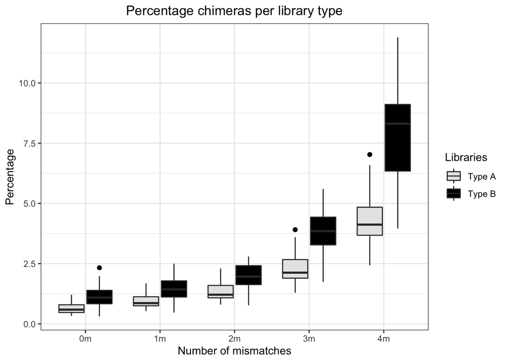

```r
###Percentage of total chimeras per library type

chimeras_percentage$Plate_type<-c(rep("Type A", 200),rep("Type B", 175))

chimeras_percentage_graph_type <- ggplot(chimeras_percentage) +
  scale_fill_grey(start = 0.9, end = 0)+
  geom_boxplot(aes(x=chimeras_percentage$Mismatches, y=chimeras_percentage$Percentage,
              fill=chimeras_percentage$Plate_type),outlier.colour="black",
               outlier.shape=16,
               outlier.size=2, notch=FALSE)+
  theme_bw()+
  xlab("Number of mismatches")+ ylab("Percentage")+labs(fill = "Libraries")+
  ggtitle("Percentage chimeras per library type")+
  theme(plot.title = element_text(hjust = 0.5))


chimeras_percentage_graph_type
```

```r
#For median, max and min values check the graph using ggplotly
#ggplotly(chimeras_percentage_graph_type)
ggsave("Figure_4_inner_chimeras_type.pdf",width = 15,height=10, units = "cm")
```

Here we have calculated the percentage of genuine reads and chimeric reads per experiment and per number of mismatches allowed for barcode rescue. TI_Results_summary includes results for experiment Type A while TII_Results_summary includes results for experiment Type B.

```r
##Get percentages of chimeras per type
#get number of cases of each type of chimera
TI<-chimeras[chimeras$Plate_type=="Type_A",]
#Percentage of chimeric sequences and genuine sequences per plate and multiplexing group
#for each number of mismatches
TI_Results= TI %>% group_by( Mismatches,Plate, Multiplexing_group, Description) %>%
  mutate(Total = sum(as.numeric(Reads)))  %>%
  summarize(Total = sum(Reads, na.rm = TRUE), Stdev=sd(Reads,na.rm = TRUE )) %>%
  mutate(Perc = 100*(as.numeric(Total)/sum(as.numeric(Total))))
#Summary statistics : median, stdev, mean, maximum and minimum percentage of chimeric and
#genuine sequences per multiplexing group
TI_Results_summary = TI_Results%>% group_by(Mismatches,Description)%>%
  select(Mismatches, Description, Perc)%>%
  summarize(Median = median(Perc, na.rm = TRUE), Stdev=sd(Perc,na.rm = TRUE),
            Mean = mean(Perc, na.rm = TRUE),Max=max(Perc), Min=min(Perc))
knitr::kable(TI_Results_summary[,])
```

| Mismatches | Description | Median | Stdev | Mean | Max | Min |
| --- | --- | --- | --- | --- | --- | --- |
| 0m | chimera | 0.5882524 | 0.2199495 | 0.6516998 | 1.206203 | 0.3273444 |
| 0m | sample | 99.4117476 | 0.2199495 | 99.3483002 | 99.672656 | 98.7937974 |
| 1m | chimera | 0.8598316 | 0.2930127 | 0.9596764 | 1.680252 | 0.5318300 |
| 1m | sample | 99.1401684 | 0.2930127 | 99.0403236 | 99.468170 | 98.3197478 |
| 2m | chimera | 1.2106550 | 0.3926914 | 1.3572615 | 2.303713 | 0.7979215 |
| 2m | sample | 98.7893450 | 0.3926914 | 98.6427385 | 99.202078 | 97.6962869 |
| 3m | chimera | 2.1267454 | 0.6241003 | 2.3305629 | 3.909302 | 1.2925978 |
| 3m | sample | 97.8732546 | 0.6241003 | 97.6694371 | 98.707402 | 96.0906975 |
| 4m | chimera | 4.1224898 | 1.0244369 | 4.3668766 | 7.029078 | 2.4256283 |
| 4m | sample | 95.8775102 | 1.0244369 | 95.6331234 | 97.574372 | 92.9709220 |

```r
#Percentage of chimeric sequences and genuine sequences per plate and number of mismatches
TI_Results_Plate<-TI %>% group_by(Plate,Mismatches) %>%
  select(Reads,Mismatches, Description, Plate)%>%
  mutate(Total = sum(as.numeric(Reads))) %>%
  group_by(Plate,Mismatches, Description) %>%
  select(Mismatches,Description,Reads,Total,Plate)%>%
  summarize(Total = sum(Reads, na.rm = TRUE), Stdev=sd(Reads,na.rm = TRUE )) %>%
  mutate(Percentage = 100*(as.numeric(Total)/sum(as.numeric(Total))))

TII<-chimeras[chimeras$Plate_type=="Type_B",]
#Percentage of chimeric sequences and genuine sequences per plate and multiplexing group
#for each number of mismatches
TII_Results= TII %>% group_by( Mismatches,Plate, Multiplexing_group, Description) %>%
  mutate(Total = sum(as.numeric(Reads)))  %>%
  summarize(Total = sum(Reads, na.rm = TRUE), Stdev=sd(Reads,na.rm = TRUE )) %>%
  mutate(Perc = 100*(as.numeric(Total)/sum(as.numeric(Total))))

#Summary statistics  median, stdev, mean, maximum and minimum percentage of chimeric and
#genuine sequences per multiplexing group
TII_Results_summary = TII_Results%>% group_by(Mismatches,Description)%>%
  select(Mismatches, Description, Perc)%>%
  summarize(Median = median(Perc, na.rm = TRUE), Stdev=sd(Perc,na.rm = TRUE),
            Mean = mean(Perc, na.rm = TRUE),Max=max(Perc), Min=min(Perc))
knitr::kable(TII_Results_summary[,])
```

| Mismatches | Description | Median | Stdev | Mean | Max | Min |
| --- | --- | --- | --- | --- | --- | --- |
| 0m | chimera | 1.088241 | 0.4352251 | 1.152936 | 2.328817 | 0.3072977 |
| 0m | sample | 98.911759 | 0.4352251 | 98.847064 | 99.692702 | 97.6711834 |
| 1m | chimera | 1.434102 | 0.4587393 | 1.443139 | 2.496934 | 0.4733237 |
| 1m | sample | 98.565898 | 0.4587393 | 98.556861 | 99.526676 | 97.5030660 |
| 2m | chimera | 1.959130 | 0.5045577 | 1.964344 | 2.803124 | 0.7680890 |
| 2m | sample | 98.040870 | 0.5045577 | 98.035656 | 99.231911 | 97.1968760 |
| 3m | chimera | 3.850941 | 0.8413196 | 3.786593 | 5.596866 | 1.7385269 |
| 3m | sample | 96.149059 | 0.8413196 | 96.213407 | 98.261473 | 94.4031337 |
| 4m | chimera | 8.308966 | 1.7653039 | 7.848177 | 11.902796 | 3.9643921 |
| 4m | sample | 91.691034 | 1.7653039 | 92.151823 | 96.035608 | 88.0972040 |

```r
#Percentage of chimeric sequences and genuine sequences per plate and number of mismatches
TII_Results_Plate<-TII %>% group_by(Plate,Mismatches) %>%
  select(Reads,Mismatches, Description, Plate)%>%
  mutate(Total = sum(as.numeric(Reads))) %>%
  group_by(Plate,Mismatches, Description) %>%
  select(Mismatches,Description,Reads,Total,Plate)%>%
  summarize(Total = sum(Reads, na.rm = TRUE), Stdev=sd(Reads,na.rm = TRUE )) %>%
  mutate(Percentage = 100*(as.numeric(Total)/sum(as.numeric(Total))))
```

## Differences are mainly find between different library types, not be-tween libraries from the same type

Here we are plotting the percentage of chimeras found for each number of mismatches allowed for barcode resuce and per plate. This graph helps us to see that differences are mainly found between experiment types, not between libraries from the same type. Statistical results can be found in Script 02_Statistics_chimeras.Rmd

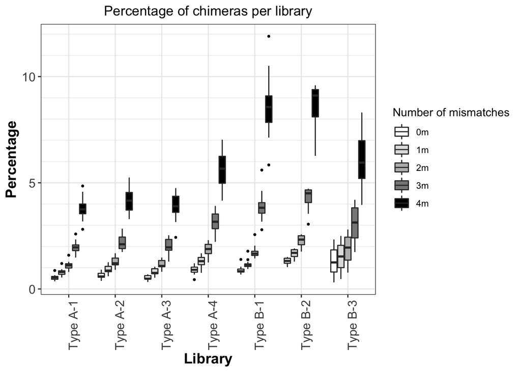

```r
###Percentage of total chimeras per Plate
chimeras_percentage_graph <- ggplot(chimeras_percentage) +
  scale_fill_grey(start = 1, end = 0)+
  geom_boxplot(aes(x=Plate, y=Percentage, fill=Mismatches),outlier.colour="black",
               outlier.shape=16,
               outlier.size=1, notch=FALSE)+
  theme_bw()+
  xlab("Library")+ ylab("Percentage")+labs(fill = "Number of mismatches")+
  ggtitle("Percentage of chimeras per library")+
  theme(plot.title = element_text(hjust = 0.5))+
  scale_y_continuous(breaks = seq(0, 25, 5),
                    minor_breaks = seq(0, 25, 1))+
  theme(axis.text=element_text(size=12),
        axis.title=element_text(size=14,face="bold"))+
  scale_fill_grey(start = 1, end = 0, na.value = "red", aesthetics = "fill")+
  theme(axis.text.x = element_text(angle = 90, hjust = 1))+
  scale_x_discrete(labels=c("Type A-1", "Type A-2","Type A-3","Type A-4","Type B-1","Type B-2","Type B-3"))

chimeras_percentage_graph
```

```r
#ggplotly(chimeras_percentage_graph)
ggsave("Figure_5_total_chimeras_library.pdf",width = 20,  units = "cm")
```

## 3.4. Types of chimeric combinations of adapters

Now we want to analyse the differences between the 4 types of chimeras identified in our dataset. This information is saved in column Type. We are interested in analyzing the percentage of each type of chimeras relative to the total number of chimeras.Therefore, we are going to removing the reads belonging to genuine samples.

First we are going to plot the total percentages of chimeras, from each Type identified per experiment. The values used are the percentage of each type of chimera per multiplexing group, summarized per experiment type.

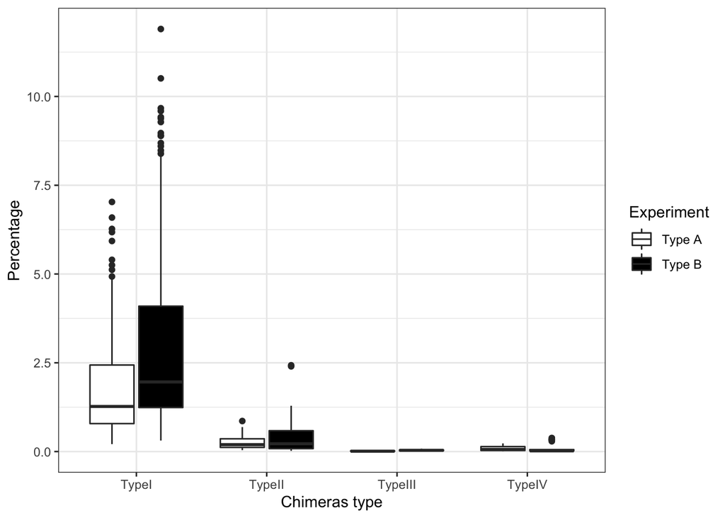

```r
#Average:
chimeras_percentage2<-chimeras %>% group_by(Plate, Multiplexing_group,Mismatches,Type) %>%
summarise(sum_counts = sum(Reads)) %>%
mutate(Total = sum(sum_counts)) %>%
mutate(Ratio = round((sum_counts)/(Total), digits = 4))%>%
mutate(Percentage=100*(Ratio))

chimeras_percentage2$Experiment<- c(rep("Type A", 500), rep("Type B",473))
chimeras_percentage2_plot<-chimeras_percentage2 %>% filter(Type != "sample")%>% group_by(Type, Experiment)
ggplot(chimeras_percentage2_plot, aes(y=Percentage, x=Type, fill=Experiment))+
  geom_boxplot()+scale_fill_grey(start = 1, end = 0)+theme_bw()+xlab("Chimeras type")
```

```r
ggsave("Figure_8_chimeras_type_percentage_total.pdf",width = 15,height=10, units = "cm")
```

Now we will keep information for each possible combination of barcodes leading to a chimeric sequence, so we can compare the relative abundance of each type of chimeras independently of the number of cases where these chimeras can be identified

```r
chimeras_indv<-chimeras %>% group_by(Plate, Mismatches) %>% mutate(ratio = Reads/sum(Reads))
chimeras_indv$Percentage<- 100*(chimeras_indv$ratio)
chimeras_indv<-chimeras_indv[chimeras_indv$Description != "sample", ]
head(chimeras)
```

```
##             Barcode Filename Plate Mismatches Multiplexing_group  Type Reads
## 1 AAGACTGG-ACCTGTTG chimera1 Seq-1         0m                  A TypeI  5514
## 2 AAGACTGG-CTGGTTCA chimera2 Seq-1         0m                  A TypeI  2088
## 3 AAGACTGG-CGACAAGA chimera3 Seq-1         0m                  A TypeI  4649
## 4 AAGACTGG-CAGTCGAA chimera4 Seq-1         0m                  A TypeI  2437
## 5 AAGACTGG-GTCAGAAC chimera5 Seq-1         0m                  A TypeI  2462
## 6 AAGACTGG-TTGTTCCG chimera6 Seq-1         0m                  A TypeI 12038
##   Description Plate_type
## 1     chimera     Type_A
## 2     chimera     Type_A
## 3     chimera     Type_A
## 4     chimera     Type_A
## 5     chimera     Type_A
## 6     chimera     Type_A
```

Results are plotted in two graphs, one for experiment type A and one for experiment type B

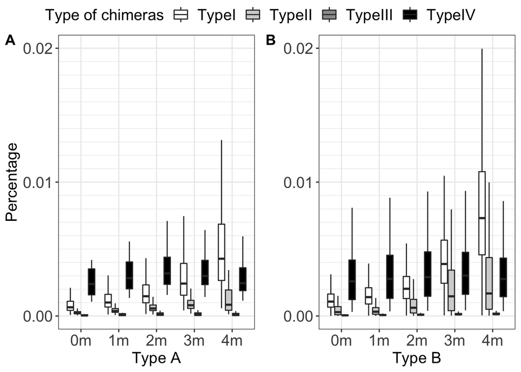

```r
######Division between non existant combinations of sequencing chimeras and existant combinations
M<-chimeras_indv[chimeras_indv$Plate_type=="Type_A",]
R<-chimeras_indv[chimeras_indv$Plate_type=="Type_B",]
par(mfrow=c(2,1))

R_chimeras_percentage_graph <- ggplot(R) +
  scale_fill_grey(start = 1, end = 0)+
  geom_boxplot(aes(x=R$Mismatches, y=R$Percentage, fill=R$Type), outlier.colour="red",
               outlier.shape=NA,
               outlier.size=2, notch=FALSE)+
  theme_bw()+
  xlab("")+
  ylab("")+labs(fill = "Type of chimeras")+xlab("Type B")+
  #ggtitle("Percentage of total chimeras")+
  theme(plot.title = element_text(hjust = 0.5))+
  scale_y_continuous(limits = c(0, 0.02),breaks = seq(0, 0.03, 0.01),
                   minor_breaks = seq(0,0.02, 0.001))+
  theme(axis.text.x = element_text(size = 15),
        axis.text.y = element_text(size = 15),
        axis.title.x = element_text(size = 15),
        axis.title.y = element_text(size = 15))+ theme(
  legend.title = element_text(size = 15),
  legend.text = element_text(size = 15)
  )

M_chimeras_percentage_graph <- ggplot(M) +
  scale_fill_grey(start = 1, end = 0)+
  geom_boxplot(aes(x=M$Mismatches, y=M$Percentage, fill=M$Type), outlier.colour="red",
               outlier.shape=NA,
               outlier.size=2, notch=FALSE)+
  theme_bw()+
  xlab("")+
  ylab("Percentage")+labs(fill = "Type of chimeras")+xlab("Type A")+
  #ggtitle("Percentage of total chimeras")+
  theme(plot.title = element_text(hjust = 0.5))+
  scale_y_continuous(limits = c(0, 0.02),breaks = seq(0, 0.03, 0.01),
                    minor_breaks = seq(0,0.02, 0.001))+
  theme(axis.text.x = element_text(size = 15),
        axis.text.y = element_text(size = 15),
        axis.title.x = element_text(size = 15),
        axis.title.y = element_text(size = 15))+ theme(
  legend.title = element_text(size = 15),
  legend.text = element_text(size = 15)
  )


ggarrange(M_chimeras_percentage_graph, R_chimeras_percentage_graph,
          labels=c("A", "B"),
          ncol = 2, nrow = 1,  align = "hv",
          common.legend = TRUE)
```

```r
ggsave("Figure_9_outer_chimeras.pdf",width = 25,  units = "cm")
```

Now, we are going to summarise our results into tables, to show the percentage of chimeras respect to the total. chimeras_percentage_plate_type table will gave us the percentage of each type of chimeras and genuine sequences per plate and per number of mismatches allowed for barcode rescue

```r
chimeras_percentage_plate_type<-chimeras %>% group_by(Plate_type,Plate,Mismatches,Type) %>%
summarise(sum_counts = sum(Reads)) %>%
mutate(Total = sum(sum_counts)) %>%
mutate(Ratio = round((sum_counts)/(Total), digits = 4))%>%
mutate(Percentage=100*(Ratio))
knitr::kable(chimeras_percentage_plate_type[,])
```

| Plate_type | Plate | Mismatches | Type | sum_counts | Total | Ratio | Percentage |
| --- | --- | --- | --- | --- | --- | --- | --- |
| Type_A | Seq-1 | 0m | sample | 463480162 | 466019185 | 0.9946 | 99.46 |
| Type_A | Seq-1 | 0m | TypeI | 2439357 | 466019185 | 0.0052 | 0.52 |
| Type_A | Seq-1 | 0m | TypeII | 68515 | 466019185 | 0.0001 | 0.01 |
| Type_A | Seq-1 | 0m | TypeIII | 784 | 466019185 | 0.0000 | 0.00 |
| Type_A | Seq-1 | 0m | TypeIV | 30367 | 466019185 | 0.0001 | 0.01 |
| Type_A | Seq-1 | 1m | sample | 475845256 | 479684324 | 0.9920 | 99.20 |
| Type_A | Seq-1 | 1m | TypeI | 3690948 | 479684324 | 0.0077 | 0.77 |
| Type_A | Seq-1 | 1m | TypeII | 109182 | 479684324 | 0.0002 | 0.02 |
| Type_A | Seq-1 | 1m | TypeIII | 1303 | 479684324 | 0.0000 | 0.00 |
| Type_A | Seq-1 | 1m | TypeIV | 37635 | 479684324 | 0.0001 | 0.01 |
| Type_A | Seq-1 | 2m | sample | 480166678 | 485600718 | 0.9888 | 98.88 |
| Type_A | Seq-1 | 2m | TypeI | 5232306 | 485600718 | 0.0108 | 1.08 |
| Type_A | Seq-1 | 2m | TypeII | 156318 | 485600718 | 0.0003 | 0.03 |
| Type_A | Seq-1 | 2m | TypeIII | 1843 | 485600718 | 0.0000 | 0.00 |
| Type_A | Seq-1 | 2m | TypeIV | 43573 | 485600718 | 0.0001 | 0.01 |
| Type_A | Seq-1 | 3m | sample | 481454172 | 491131425 | 0.9803 | 98.03 |
| Type_A | Seq-1 | 3m | TypeI | 9404089 | 491131425 | 0.0191 | 1.91 |
| Type_A | Seq-1 | 3m | TypeII | 228429 | 491131425 | 0.0005 | 0.05 |
| Type_A | Seq-1 | 3m | TypeIII | 2429 | 491131425 | 0.0000 | 0.00 |
| Type_A | Seq-1 | 3m | TypeIV | 42306 | 491131425 | 0.0001 | 0.01 |
| Type_A | Seq-1 | 4m | sample | 479245866 | 498253668 | 0.9619 | 96.19 |
| Type_A | Seq-1 | 4m | TypeI | 18646797 | 498253668 | 0.0374 | 3.74 |
| Type_A | Seq-1 | 4m | TypeII | 323116 | 498253668 | 0.0006 | 0.06 |
| Type_A | Seq-1 | 4m | TypeIII | 2675 | 498253668 | 0.0000 | 0.00 |
| Type_A | Seq-1 | 4m | TypeIV | 35214 | 498253668 | 0.0001 | 0.01 |
| Type_A | Seq-2 | 0m | sample | 448446893 | 451288723 | 0.9937 | 99.37 |
| Type_A | Seq-2 | 0m | TypeI | 2702044 | 451288723 | 0.0060 | 0.60 |
| Type_A | Seq-2 | 0m | TypeII | 72238 | 451288723 | 0.0002 | 0.02 |
| Type_A | Seq-2 | 0m | TypeIII | 3373 | 451288723 | 0.0000 | 0.00 |
| Type_A | Seq-2 | 0m | TypeIV | 64175 | 451288723 | 0.0001 | 0.01 |

[output cut: 140 more lines]

chimeras_percentage_plate table will gave us the total percentage of chimeras and genuine sequences per plate and per number of mismatches allowed for barcode rescue

```r
chimeras_percentage_plate<-chimeras %>% group_by(Plate,Mismatches, Plate_type,Description) %>%
summarise(sum_counts = sum(Reads)) %>%
mutate(Total = sum(sum_counts)) %>%
mutate(Ratio = round((sum_counts)/(Total), digits = 4))%>%
mutate(Percentage=100*(Ratio))

knitr::kable(chimeras_percentage_plate[,])
```

| Plate | Mismatches | Plate_type | Description | sum_counts | Total | Ratio | Percentage |
| --- | --- | --- | --- | --- | --- | --- | --- |
| Seq-1 | 0m | Type_A | chimera | 2539023 | 466019185 | 0.0054 | 0.54 |
| Seq-1 | 0m | Type_A | sample | 463480162 | 466019185 | 0.9946 | 99.46 |
| Seq-1 | 1m | Type_A | chimera | 3839068 | 479684324 | 0.0080 | 0.80 |
| Seq-1 | 1m | Type_A | sample | 475845256 | 479684324 | 0.9920 | 99.20 |
| Seq-1 | 2m | Type_A | chimera | 5434040 | 485600718 | 0.0112 | 1.12 |
| Seq-1 | 2m | Type_A | sample | 480166678 | 485600718 | 0.9888 | 98.88 |
| Seq-1 | 3m | Type_A | chimera | 9677253 | 491131425 | 0.0197 | 1.97 |
| Seq-1 | 3m | Type_A | sample | 481454172 | 491131425 | 0.9803 | 98.03 |
| Seq-1 | 4m | Type_A | chimera | 19007802 | 498253668 | 0.0381 | 3.81 |
| Seq-1 | 4m | Type_A | sample | 479245866 | 498253668 | 0.9619 | 96.19 |
| Seq-2 | 0m | Type_A | chimera | 2841830 | 451288723 | 0.0063 | 0.63 |
| Seq-2 | 0m | Type_A | sample | 448446893 | 451288723 | 0.9937 | 99.37 |
| Seq-2 | 1m | Type_A | chimera | 4266492 | 465755795 | 0.0092 | 0.92 |
| Seq-2 | 1m | Type_A | sample | 461489303 | 465755795 | 0.9908 | 99.08 |
| Seq-2 | 2m | Type_A | chimera | 6013225 | 472222543 | 0.0127 | 1.27 |
| Seq-2 | 2m | Type_A | sample | 466209318 | 472222543 | 0.9873 | 98.73 |
| Seq-2 | 3m | Type_A | chimera | 10479748 | 478261210 | 0.0219 | 2.19 |
| Seq-2 | 3m | Type_A | sample | 467781462 | 478261210 | 0.9781 | 97.81 |
| Seq-2 | 4m | Type_A | chimera | 20256683 | 485958127 | 0.0417 | 4.17 |
| Seq-2 | 4m | Type_A | sample | 465701444 | 485958127 | 0.9583 | 95.83 |
| Seq-3 | 0m | Type_A | chimera | 2326712 | 460199409 | 0.0051 | 0.51 |
| Seq-3 | 0m | Type_A | sample | 457872697 | 460199409 | 0.9949 | 99.49 |
| Seq-3 | 1m | Type_A | chimera | 3682514 | 476817484 | 0.0077 | 0.77 |
| Seq-3 | 1m | Type_A | sample | 473134970 | 476817484 | 0.9923 | 99.23 |
| Seq-3 | 2m | Type_A | chimera | 5377654 | 483284565 | 0.0111 | 1.11 |
| Seq-3 | 2m | Type_A | sample | 477906911 | 483284565 | 0.9889 | 98.89 |
| Seq-3 | 3m | Type_A | chimera | 9469174 | 488845037 | 0.0194 | 1.94 |
| Seq-3 | 3m | Type_A | sample | 479375863 | 488845037 | 0.9806 | 98.06 |
| Seq-3 | 4m | Type_A | chimera | 18476013 | 495827138 | 0.0373 | 3.73 |
| Seq-3 | 4m | Type_A | sample | 477351125 | 495827138 | 0.9627 | 96.27 |
| Seq-4 | 0m | Type_A | chimera | 3747878 | 428643112 | 0.0087 | 0.87 |
| Seq-4 | 0m | Type_A | sample | 424895234 | 428643112 | 0.9913 | 99.13 |
| Seq-4 | 1m | Type_A | chimera | 5715071 | 448688376 | 0.0127 | 1.27 |
| Seq-4 | 1m | Type_A | sample | 442973305 | 448688376 | 0.9873 | 98.73 |
| Seq-4 | 2m | Type_A | chimera | 8363205 | 458850192 | 0.0182 | 1.82 |
| Seq-4 | 2m | Type_A | sample | 450486987 | 458850192 | 0.9818 | 98.18 |
| Seq-4 | 3m | Type_A | chimera | 14481635 | 467674524 | 0.0310 | 3.10 |
| Seq-4 | 3m | Type_A | sample | 453192889 | 467674524 | 0.9690 | 96.90 |
| Seq-4 | 4m | Type_A | chimera | 26464536 | 476149329 | 0.0556 | 5.56 |
| Seq-4 | 4m | Type_A | sample | 449684793 | 476149329 | 0.9444 | 94.44 |
| Seq+PCR-1 | 0m | Type_B | chimera | 3059545 | 353302804 | 0.0087 | 0.87 |
| Seq+PCR-1 | 0m | Type_B | sample | 350243259 | 353302804 | 0.9913 | 99.13 |
| Seq+PCR-1 | 1m | Type_B | chimera | 4241127 | 369234055 | 0.0115 | 1.15 |
| Seq+PCR-1 | 1m | Type_B | sample | 364992928 | 369234055 | 0.9885 | 98.85 |
| Seq+PCR-1 | 2m | Type_B | chimera | 6474128 | 378300170 | 0.0171 | 1.71 |
| Seq+PCR-1 | 2m | Type_B | sample | 371826042 | 378300170 | 0.9829 | 98.29 |
| Seq+PCR-1 | 3m | Type_B | chimera | 15049575 | 391519214 | 0.0384 | 3.84 |
| Seq+PCR-1 | 3m | Type_B | sample | 376469639 | 391519214 | 0.9616 | 96.16 |
| Seq+PCR-1 | 4m | Type_B | chimera | 35085303 | 410641458 | 0.0854 | 8.54 |
| Seq+PCR-1 | 4m | Type_B | sample | 375556155 | 410641458 | 0.9146 | 91.46 |
| Seq+PCR-2 | 0m | Type_B | chimera | 4461806 | 339219911 | 0.0132 | 1.32 |
| Seq+PCR-2 | 0m | Type_B | sample | 334758105 | 339219911 | 0.9868 | 98.68 |
| Seq+PCR-2 | 1m | Type_B | chimera | 6032957 | 357098617 | 0.0169 | 1.69 |
| Seq+PCR-2 | 1m | Type_B | sample | 351065660 | 357098617 | 0.9831 | 98.31 |
| Seq+PCR-2 | 2m | Type_B | chimera | 8411121 | 366258030 | 0.0230 | 2.30 |
| Seq+PCR-2 | 2m | Type_B | sample | 357846909 | 366258030 | 0.9770 | 97.70 |
| Seq+PCR-2 | 3m | Type_B | chimera | 16288765 | 378307447 | 0.0431 | 4.31 |
| Seq+PCR-2 | 3m | Type_B | sample | 362018682 | 378307447 | 0.9569 | 95.69 |
| Seq+PCR-2 | 4m | Type_B | chimera | 34275084 | 395374132 | 0.0867 | 8.67 |
| Seq+PCR-2 | 4m | Type_B | sample | 361099048 | 395374132 | 0.9133 | 91.33 |
| Seq+PCR-3 | 0m | Type_B | chimera | 4572257 | 364236040 | 0.0126 | 1.26 |
| Seq+PCR-3 | 0m | Type_B | sample | 359663783 | 364236040 | 0.9874 | 98.74 |
| Seq+PCR-3 | 1m | Type_B | chimera | 5502386 | 379849446 | 0.0145 | 1.45 |
| Seq+PCR-3 | 1m | Type_B | sample | 374347060 | 379849446 | 0.9855 | 98.55 |
| Seq+PCR-3 | 2m | Type_B | chimera | 7000880 | 386504911 | 0.0181 | 1.81 |
| Seq+PCR-3 | 2m | Type_B | sample | 379504031 | 386504911 | 0.9819 | 98.19 |
| Seq+PCR-3 | 3m | Type_B | chimera | 12018668 | 394022833 | 0.0305 | 3.05 |
| Seq+PCR-3 | 3m | Type_B | sample | 382004165 | 394022833 | 0.9695 | 96.95 |
| Seq+PCR-3 | 4m | Type_B | chimera | 24459083 | 405062580 | 0.0604 | 6.04 |
| Seq+PCR-3 | 4m | Type_B | sample | 380603497 | 405062580 | 0.9396 | 93.96 |

In order to calculate the Experiment percentages, we used the chimeras_percentage2 files, wich includes the percentages for each combination of barcodes leading to chimeras. This way the numbers obtained will be more precised

```r
chimeras_percentage_per_experiment_and_case=chimeras_percentage2 %>% group_by(Experiment, Type,Mismatches)%>%summarize(mean_percentage=mean(Percentage) )
chimeras_percentage_per_experiment_and_case
```

```
## # A tibble: 50 × 4
## # Groups:   Experiment, Type [10]
##    Experiment Type   Mismatches mean_percentage
##    <chr>      <chr>  <chr>                <dbl>
##  1 Type A     sample 0m                  99.3
##  2 Type A     sample 1m                  99.0
##  3 Type A     sample 2m                  98.6
##  4 Type A     sample 3m                  97.7
##  5 Type A     sample 4m                  95.6
##  6 Type A     TypeI  0m                   0.617
##  7 Type A     TypeI  1m                   0.908
##  8 Type A     TypeI  2m                   1.29
##  9 Type A     TypeI  3m                   2.24
## 10 Type A     TypeI  4m                   4.25
## # … with 40 more rows
```

```r
chimeras_percentage_per_experiment=chimeras_percentage2 %>% filter(Type != "sample")%>%group_by(Experiment, Plate,Multiplexing_group, Mismatches)%>%summarize(sum_percentage=sum(Percentage) )%>%group_by(Experiment, Plate, Mismatches)%>%summarize(mean_percentage=mean(sum_percentage) )%>%group_by(Experiment, Mismatches)%>%summarize(mean_percentage_exp=mean(mean_percentage) )
chimeras_percentage_per_experiment
```

```
## # A tibble: 10 × 3
## # Groups:   Experiment [2]
##    Experiment Mismatches mean_percentage_exp
##    <chr>      <chr>                    <dbl>
##  1 Type A     0m                       0.652
##  2 Type A     1m                       0.960
##  3 Type A     2m                       1.36
##  4 Type A     3m                       2.33
##  5 Type A     4m                       4.37
##  6 Type B     0m                       1.16
##  7 Type B     1m                       1.44
##  8 Type B     2m                       1.96
##  9 Type B     3m                       3.77
## 10 Type B     4m                       7.80
```

Here we get the percetage of each type of chimera relative to the total number of chimeras (reads from genuine samples have been excluded)

```r
#get number of cases for each type of chimera in each library preparation protocol (Percentage of each type of chimeras relative to the total number of chimeras)
TI<-chimeras_indv[chimeras_indv$Plate_type=="Type_A",]
TII<-chimeras_indv[chimeras_indv$Plate_type=="Type_B",]
Table_TI<-as.data.frame(table(TI$Type))
Table_TI$Percentage<-((Table_TI$Freq)/sum(Table_TI$Freq))*100

Table_TII<-as.data.frame(table(TII$Type))
Table_TII$Percentage<-((Table_TII$Freq)/sum(Table_TII$Freq))*100


Table<-merge(Table_TI,Table_TII, by = "Var1")
colnames(Table)<-c("Type","TypeI","Percentage_TypeI","TypeII","Percentage_TypeII")
Table<-Table %>% remove_rownames %>% column_to_rownames(var="Type")
Table<-Table[-c(1,3)]
Table
```

```
##         Percentage_TypeI Percentage_TypeII
## TypeI         91.4364641        88.4409449
## TypeII         7.1823204         8.8031496
## TypeIII        0.8287293         1.9685039
## TypeIV         0.5524862         0.7874016
```

# Expected and observed number of chimeras type IV

All the calculations will be done considering no mismatches for barcode rescue

```r
# Type A

# Here we get the total number of reads for the plates belonging to experiment type Seq
Total_number_type_seq<-chimeras_percentage2 %>% filter(Mismatches == "0m", Experiment=="Type A",Type=="sample") %>% ungroup() %>%
summarise(sum(Total))
Total_number_type_seq
```

```
## # A tibble: 1 × 1
##   `sum(Total)`
##          <int>
## 1   1806150429
```

```r
# Here we calculate the number of chimeras type IV for experiment type Seq
Total_number_type_IV_type_seq<-chimeras_percentage2 %>% filter(Mismatches == "0m", Experiment=="Type A",Type=="TypeIV") %>% ungroup() %>%
summarise(sum(sum_counts))
Total_number_type_IV_type_seq
```

```
## # A tibble: 1 × 1
##   `sum(sum_counts)`
##               <int>
## 1            182768
```

```r
#Here we get the total number of reads from the multiplexing groups containing chimeras type IV
Total_reads_multiplexing_groups_type_IV_type_seq<-chimeras_percentage2 %>% filter(Mismatches == "0m", Experiment=="Type A",Type=="TypeIV") %>% ungroup() %>% summarise(sum(Total))
Total_reads_multiplexing_groups_type_IV_type_seq
```

```
## # A tibble: 1 × 1
##   `sum(Total)`
##          <int>
## 1    262636890
```

```r
#Type IV
Observed_proportion_TIV_seq<-(Total_number_type_IV_type_seq/Total_reads_multiplexing_groups_type_IV_type_seq)
Expected_TIV_seq<-(((Total_number_type_IV_type_seq/Total_reads_multiplexing_groups_type_IV_type_seq)*360)/16)*Total_number_type_seq
Expected_proportion_TIV_seq<-(Expected_TIV_seq/Total_number_type_seq)
Observed_proportion_TIV_seq
```

```
##   sum(sum_counts)
## 1    0.0006958961
```

```r
Expected_TIV_seq
```

```
##   sum(sum_counts)
## 1        28280095
```

```r
Expected_proportion_TIV_seq
```

```
##   sum(sum_counts)
## 1      0.01565766
```

```r
##Type B
#Here we get the total number of reads for the plates belonging to experiment type Seq
Total_number_type_seq_pcr<-chimeras_percentage2 %>% filter(Mismatches == "0m", Experiment=="Type B",Type=="sample") %>% ungroup() %>%
summarise(sum(Total))
Total_number_type_seq_pcr
```

```
## # A tibble: 1 × 1
##   `sum(Total)`
##          <int>
## 1   1056758755
```

```r
# Here we calculate the number of chimeras type IV for experiment type Seq+PCR
Total_number_type_IV_type_seq_pcr<-chimeras_percentage2 %>% filter(Mismatches == "0m", Experiment=="Type B",Type=="TypeIV") %>% ungroup() %>%
summarise(sum(sum_counts))
Total_number_type_IV_type_seq_pcr
```

```
## # A tibble: 1 × 1
##   `sum(sum_counts)`
##               <int>
## 1            205518
```

```r
#Here we get the total number of reads from the multiplexing groups containing chimeras type IV
Total_reads_multiplexing_groups_type_IV_type_seq_pcr<-chimeras_percentage2 %>% filter(Mismatches == "0m", Experiment=="Type B",Type=="TypeIV") %>% ungroup() %>% summarise(sum(Total))
Total_reads_multiplexing_groups_type_IV_type_seq_pcr
```

```
## # A tibble: 1 × 1
##   `sum(Total)`
##          <int>
## 1    285075135
```

```r
#Type IV
Observed_proportion_TIV_seq_pcr<-(Total_number_type_IV_type_seq_pcr/Total_reads_multiplexing_groups_type_IV_type_seq_pcr)
Expected_TIV_seq_pcr<-(((Total_number_type_IV_type_seq_pcr/Total_reads_multiplexing_groups_type_IV_type_seq_pcr)*360)/20)*Total_number_type_seq_pcr
Expected_proportion_TIV_seq_pcr<-(Expected_TIV_seq_pcr/Total_number_type_seq_pcr)
Observed_proportion_TIV_seq_pcr
```

```
##   sum(sum_counts)
## 1    0.0007209257
```

```r
Expected_TIV_seq_pcr
```

```
##   sum(sum_counts)
## 1        13713202
```

```r
Expected_proportion_TIV_seq_pcr
```

```
##   sum(sum_counts)
## 1      0.01297666
```

Now we want to get the percentage respect to the total of reads, not relative to the total of chimeras to compare the detected and undetected percentages of chimeras Type IV

```r
#Total reads
Table_total_reads<-chimeras_percentage2%>%filter(Mismatches=="0m")%>%
  filter(Type!="sample")%>%
  group_by(Multiplexing_group, Plate) %>%
  summarise(chimeras_multiplexing_group = sum(sum_counts)) %>%
  group_by(Plate)%>%
  summarise(sum_plate = sum(chimeras_multiplexing_group))
Table_total_reads$Experiment=c(rep("Type A", 4), rep("Type B", 3))
Table_total_reads<-Table_total_reads%>%
  group_by(Experiment)%>%
  summarise(sum_experiment = sum(sum_plate))
Table_total_reads
```

```
## # A tibble: 2 × 2
##   Experiment sum_experiment
##   <chr>               <int>
## 1 Type A           11455443
## 2 Type B           12093608
```

```r
Percentage_chimeras_detected_Type_A=(Table_total_reads$sum_experiment[1]/Total_number_type_seq)*100
Percentage_chimeras_detected_Type_A
```

```
##   sum(Total)
## 1  0.6342463
```

```r
Percentage_undetected_Type_A= (Expected_TIV_seq/Total_number_type_seq)*100
Percentage_undetected_Type_A
```

```
##   sum(sum_counts)
## 1        1.565766
```

```r
Total_percentage_chimeras_Type_A=(sum(Table_total_reads$sum_experiment[1]+Expected_TIV_seq)/Total_number_type_seq)*100
Total_percentage_chimeras_Type_A
```

```
##   sum(Total)
## 1   2.200013
```

```r
Percentage_chimeras_detected_Type_B=(Table_total_reads$sum_experiment[2]/Total_number_type_seq_pcr)*100
Percentage_chimeras_detected_Type_B
```

```
##   sum(Total)
## 1   1.144406
```

```r
Percentage_undetected_Type_B=(Expected_TIV_seq_pcr/Total_number_type_seq_pcr)*100
Percentage_undetected_Type_B
```

```
##   sum(sum_counts)
## 1        1.297666
```

```r
Total_percentage_chimeras_Type_B=(sum(Table_total_reads$sum_experiment[2]+Expected_TIV_seq_pcr)/Total_number_type_seq_pcr)*100
Total_percentage_chimeras_Type_B
```

```
##   sum(Total)
## 1   2.442072
```